# Lab10.1 - Weighted Least Squares (WLS)

Adam Garber

Factor Analysis ED 216B - Instructor: Karen Nylund-Gibson

March 30, 2020

# 1 Getting started: Rprojects, Rmarkdown, Git-Github

- [$\color{blue}{\text{R-studio, R-Projects, Scripts: Go here}}$](https://rstudio-conf-2020.github.io/r-for-excel/rstudio.html)
- [$\color{blue}{\text{Rmarkdown basics tutorial: Go here (also chapters 3 and 4 from above link) here}}$](https://rmarkdown.rstudio.com/lesson-1.html)
- [$\color{blue}{\text{Connect Git-Hithub with R-studio and download Repositories: Go here}}$](https://docs.google.com/document/d/1zx2upJJqFZe94O3BQSMI56Z76s3haLXC0otKSpcZaJQ/edit)

# 2 Steps to download repositories from Github and create a version controlled R-project

0. Create a Github account and connect R-Studio with Git
1. Go to the Lab10 repository link to **Fork** and **Clone** (copy address) the repository:
2. Within R-studio create a **New project** and choose the **Version Control** Option (Git)
3. Paste the repository address copied (cloned) from Github and save locally on your computer
4. After making changes in your branch of the repository to update the version on Github follow the following sequence of steps: `Stage`, `Commit` (add commit message), `Pull`, and then `Push`

# 3 **Outline**

- Prepare data
- EFA (model 0)
- CFA (models 1-3)
- Invariance (models 4-7)
- Generate summary table for model comparison

DATA SOURCE: This lab exercise utilizes a subset of the HSLS public-use dataset: High School Longitudinal Study of 2009 (Ingels et al., 2011) [$\color{blue}{\text{See website: nces.ed.gov}}$](https://nces.ed.gov/pubsearch/pubsinfo.asp?pubid=2018142)

FURTHER READING: A description of the models run in this lab exercise can be found in chapter 16 (page 411) in Kline, 2016. All specifications for invariance with the WLS estimator follow the recomendations found in this book. [$\color{blue}{\text{Example Mplus Syntax}}$](https://www.guilford.com/companion-site/Principles-and-Practice-of-Structural-Equation-Modeling-Fourth-Edition/9781462523344)

## 3.1 When to use the Weighted Least Squared (WSL) method?

1. you have ordinal indicators (e.g., Likert scales)
2. you have categorical indicators (e.g., binary, or nominal)
3. you have a combination of ordinal, categorical, and/or continuous indicators
4. you have skewed continuous indicators

## 3.2 How to specify the Robust WSL estimator (WLSMV) in Mplus

Include the following lines of syntax:

- `categorical = X1 X2 X3... ;` *identify any categorical indicators*
- `estimator = wlsmv;`
- `parameterization = theta;` *to allow for error variances to be freely estimated across groups*

## 3.3 Interpretation of $\chi^2$ with WLS estimator

- Cannot do normal chi-square difference tests (use the `DIFFTEST` option)
- The scaled Satorra-Bentler correction is required

```r
# load packages
library(MplusAutomation)
library(haven)
library(rhdf5)
library(tidyverse)
library(here)
library(corrplot)
library(kableExtra)
library(reshape2)
library(semPlot)
library(gt)
```

# 4 Prepare data

## 4.1 Read in data

```r
data_raw <- read_csv(here("data", "hsls_fa_data_subset.csv"))
```

## 4.2 Reverse code for factor interpretation

```r
hsls_data <- data_raw

cols = c("S1MPERS1", "S1MPERS2", "S1MUSELI", "S1MUSECL", "S1MUSEJO",
         "S1MTESTS", "S1MTEXTB", "S1MSKILL", "S1MASSEX", "S1MENJNG",
         "S1SPERS1", "S1SPERS2", "S1SUSELI", "S1SUSECL", "S1SUSEJO",
         "S1STESTS", "S1STEXTB", "S1SSKILL", "S1SASSEX", "S1SENJNG")

hsls_data[ ,cols] <-  5 - hsls_data[ ,cols]
```

## 4.3 Check correlations of science indicators

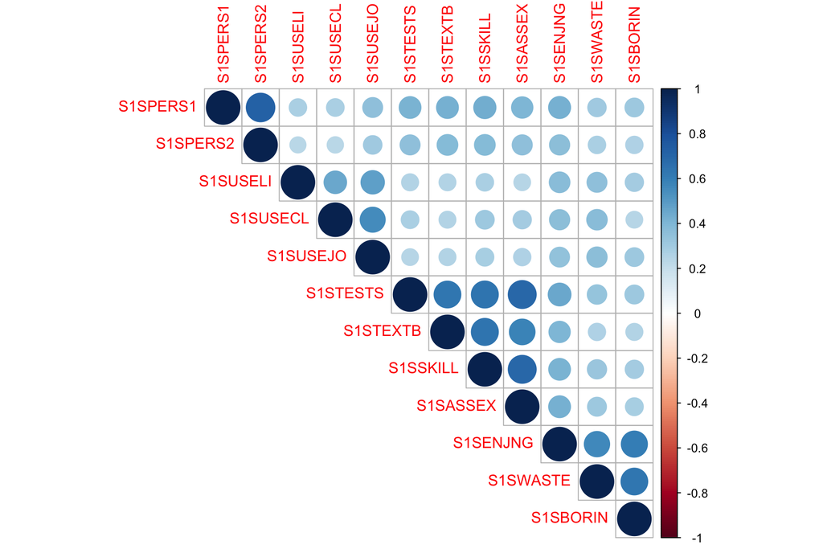

```r
sci_cor <- cor(hsls_data[27:38], use = "pairwise.complete.obs")
#sci_cor

corrplot(sci_cor,
         method = "circle",
         type = "upper")
```

```r
# NOTE: correlations should be reported from Mplus output (polychoric)
# the matrix estimated using "cor()" are not polychoric correlations
```